# Project_report

Elbrus Gasimov, Gunneet Singh

2022-09-06

## Reproduction of the original study

### Installing necessary libraries

```r
#install.packages('e1071')
library(e1071)
#install.packages('caTools')
library(caTools)
#install.packages('class')
library(class)
library(ggplot2)
```

### Loading the dataset

```r
data <- read.csv(file.choose(), header = FALSE)
```

### Adding headers to the columns

```r
colnames(data) <- c('sample_code_number',
                    'clump_Thickness',
                    'uniformity_of_cell_size',
                    'uniformity_of_cell_shape',
                    'marginal_adhesion',
                    'single_epithelial_cell_size',
                    'bare_nuclei',
                    'bland_chromatin',
                    'normal_nucleoli',
                    'mitoses',
                    'class')
```

### Overview of the data

```r
# Checking shape of data
dim(data)
```

```
## [1] 699  11
```

```r
# Checking structure of dataset
str(data)
```

```
## 'data.frame':    699 obs. of  11 variables:
##  $ sample_code_number         : int  1000025 1002945 1015425 1016277 1017023 1017122 1018099 1018561 1033078 1033078 ...
##  $ clump_Thickness            : int  5 5 3 6 4 8 1 2 2 4 ...
##  $ uniformity_of_cell_size    : int  1 4 1 8 1 10 1 1 1 2 ...
##  $ uniformity_of_cell_shape   : int  1 4 1 8 1 10 1 2 1 1 ...
##  $ marginal_adhesion          : int  1 5 1 1 3 8 1 1 1 1 ...
##  $ single_epithelial_cell_size: int  2 7 2 3 2 7 2 2 2 2 ...
##  $ bare_nuclei                : chr  "1" "10" "2" "4" ...
##  $ bland_chromatin            : int  3 3 3 3 3 9 3 3 1 2 ...
##  $ normal_nucleoli            : int  1 2 1 7 1 7 1 1 1 1 ...
##  $ mitoses                    : int  1 1 1 1 1 1 1 1 5 1 ...
##  $ class                      : int  2 2 2 2 2 4 2 2 2 2 ...
```

The dataset has 699 observations for 11 different features. Out of the total 11 variables, only the seventh column named bare_nuclei has character type values, while all others have integers.

### Distribution of “class” variable

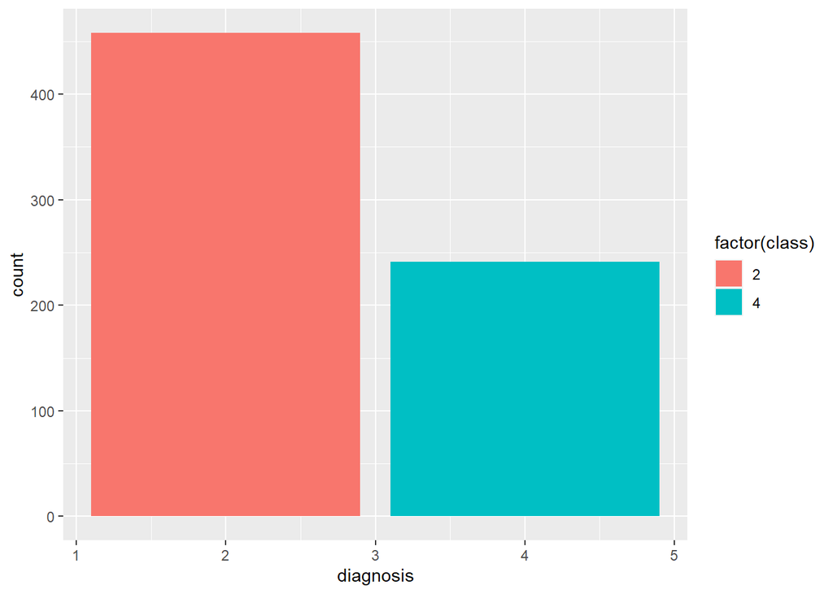

```r
ggplot(data = data, aes(class, fill = factor(class)))+
  geom_bar() + xlab("diagnosis")
```

### Data pre-processing

```r
# Converting bare_nuclei from character datatype to integer

data$bare_nuclei <- as.integer(data$bare_nuclei)
```

Before going further, we have to remove the missing values present in our data for further analysis.

```r
# Dropping all NA values

data <- na.omit(data)

dim(data)
```

```
## [1] 683  11
```

Clearly, there were missing values in 16 rows, which were removed from the dataset for further analysis.

### Building models

#### Train-Test data split

```r
set.seed(123)

split <- sample.split(data)   # random sampling of the data

train <- subset(data, split == 'TRUE')
test <- subset(data, split == 'FALSE')
```

#### Creating K-Nearest Neighbor model

We do not need the eleventh variable named Class for building the models

```r
knn_model <- knn(train = train[-11],test = test[-11], cl = train$class, k = 3)
```

#### Confusion Matrix of KNN

```r
cm1 <- table(test$class, knn_model)
cm1
```

```
##    knn_model
##       2   4
##   2 118  45
##   4  54  31
```

#### Checking the accuracy of KNN

```r
misClassError <- mean(knn_model != test$class)
print(paste('Accuracy =', 1-misClassError))
```

```
## [1] "Accuracy = 0.600806451612903"
```

Surely, the accuracy is not good enough here for any sort of predictions or further analysis. However, what is even more interesting is the fact that in the research paper, the accuracy corresponding to KNN model is around 97% which is significantly higher than what we got here.

The reason behind this stark difference has to be the unclarity in the article regarding various things including the exact proportion chosen for the modeling purposes, or any additional tuning of the parameters of the algorithm.

#### Naive Bayes Algorithm

```r
nb_model <- naiveBayes(class ~ ., data = train)
nb_model
```

```
##
## Naive Bayes Classifier for Discrete Predictors
##
## Call:
## naiveBayes.default(x = X, y = Y, laplace = laplace)
##
## A-priori probabilities:
## Y
##        2        4
## 0.645977 0.354023
##
## Conditional probabilities:
##    sample_code_number
## Y        [,1]     [,2]
##   2 1142870.4 893189.1
##   4  985188.1 344077.6
##
##    clump_Thickness
## Y       [,1]     [,2]
##   2 2.875445 1.674004
##   4 6.987013 2.468063
##
##    uniformity_of_cell_size
## Y       [,1]      [,2]
##   2 1.295374 0.8545759
##   4 6.396104 2.6750330
##
##    uniformity_of_cell_shape
## Y       [,1]      [,2]
##   2 1.377224 0.9142019
##   4 6.474026 2.5647129
##
##    marginal_adhesion
## Y       [,1]      [,2]
##   2 1.377224 0.9928571
##   4 5.668831 3.1706481
##
##    single_epithelial_cell_size
## Y      [,1]      [,2]
##   2 2.16726 0.9583073
##   4 5.25974 2.4167314
##
##    bare_nuclei
## Y       [,1]     [,2]
##   2 1.380783 1.312381
##   4 7.844156 3.001372
##
##    bland_chromatin
## Y       [,1]     [,2]
##   2 2.046263 1.032332
##   4 5.948052 2.239842
##
##    normal_nucleoli
## Y       [,1]      [,2]
##   2 1.238434 0.8640125
##   4 5.941558 3.3200461
##
##    mitoses
## Y       [,1]      [,2]
##   2 1.067616 0.5200113
##   4 2.564935 2.6219918
```

#### Generating the predicts based on NB model

```r
prediction <- predict(nb_model, newdata = test[-11])
```

#### Confusion matrix based on the “predictions”

```r
cm2 <- table(test$class, prediction)
cm2
```

```
##    prediction
##       2   4
##   2 157   6
##   4   1  84
```

#### Assessing the accuracy of Naive Bayes

```r
correct_values <- cm2[1,1]+cm2[2,2]
total_values <- correct_values + cm2[1,2] + cm2[2,1]

acc <- correct_values/total_values
print(paste('Accuracy = ', acc))
```

```
## [1] "Accuracy =  0.971774193548387"
```

Interestingly enough, the accuracy of the NB algorithm comes out to be really good. Even though it is not the same as that in the original study, it surely is very close to the actual number. This means that the unavailability of proper description about the use of algorithm does not have a huge implication here in comparison with the KNN model.

## Replication of above with some improvements

### Loading the necessary Packages

```r
#install.packages('caTools')
#install.packages('class')
#install.packages('ggplot2')
#install.packages('reshape2')
#install.packages('caret')
#install.packages('mlbench')
#install.packages('e1071')
library(caTools)
library(class)
library(ggplot2)
library(reshape2)
library(caret)
library(mlbench)
library(e1071)
```

### Loading the dataset and cheking the few rows.

```r
datarepl <- read.csv(file.choose())

head(datarepl)        # Checking first few rows
```

```
##   X1000025 X5 X1 X1.1 X1.2 X2 X1.3 X3 X1.4 X1.5 X2.1
## 1  1002945  5  4    4    5  7   10  3    2    1    2
## 2  1015425  3  1    1    1  2    2  3    1    1    2
## 3  1016277  6  8    8    1  3    4  3    7    1    2
## 4  1017023  4  1    1    3  2    1  3    1    1    2
## 5  1017122  8 10   10    8  7   10  9    7    1    4
## 6  1018099  1  1    1    1  2   10  3    1    1    2
```

The data looks a bit more complex with no clear headers assigned lets make handle it first.

### Adding headers to data to increase readability.

```r
colnames(datarepl) <- c('sample_code_number',
                    'clump_Thickness',
                    'uniformity_of_cell_size',
                    'uniformity_of_cell_shape',
                    'marginal_adhesion',
                    'single_epithelial_cell_size',
                    'bare_nuclei',
                    'bland_chromatin',
                    'normal_nucleoli',
                    'mitoses',
                    'class')
```

### Overview of the dataset

```r
# checking structure of dataset
summary(datarepl)
```

```
##  sample_code_number clump_Thickness  uniformity_of_cell_size
##  Min.   :   61634   Min.   : 1.000   Min.   : 1.000
##  1st Qu.:  870258   1st Qu.: 2.000   1st Qu.: 1.000
##  Median : 1171710   Median : 4.000   Median : 1.000
##  Mean   : 1071807   Mean   : 4.417   Mean   : 3.138
##  3rd Qu.: 1238354   3rd Qu.: 6.000   3rd Qu.: 5.000
##  Max.   :13454352   Max.   :10.000   Max.   :10.000
##  uniformity_of_cell_shape marginal_adhesion single_epithelial_cell_size
##  Min.   : 1.000           Min.   : 1.000    Min.   : 1.000
##  1st Qu.: 1.000           1st Qu.: 1.000    1st Qu.: 2.000
##  Median : 1.000           Median : 1.000    Median : 2.000
##  Mean   : 3.211           Mean   : 2.809    Mean   : 3.218
##  3rd Qu.: 5.000           3rd Qu.: 4.000    3rd Qu.: 4.000
##  Max.   :10.000           Max.   :10.000    Max.   :10.000
##  bare_nuclei        bland_chromatin  normal_nucleoli    mitoses
##  Length:698         Min.   : 1.000   Min.   : 1.00   Min.   : 1.00
##  Class :character   1st Qu.: 2.000   1st Qu.: 1.00   1st Qu.: 1.00
##  Mode  :character   Median : 3.000   Median : 1.00   Median : 1.00
##                     Mean   : 3.438   Mean   : 2.87   Mean   : 1.59
##                     3rd Qu.: 5.000   3rd Qu.: 4.00   3rd Qu.: 1.00
##                     Max.   :10.000   Max.   :10.00   Max.   :10.00
##      class
##  Min.   :2.000
##  1st Qu.:2.000
##  Median :2.000
##  Mean   :2.691
##  3rd Qu.:4.000
##  Max.   :4.000
```

### Plotting the Class variable to see the distribution.

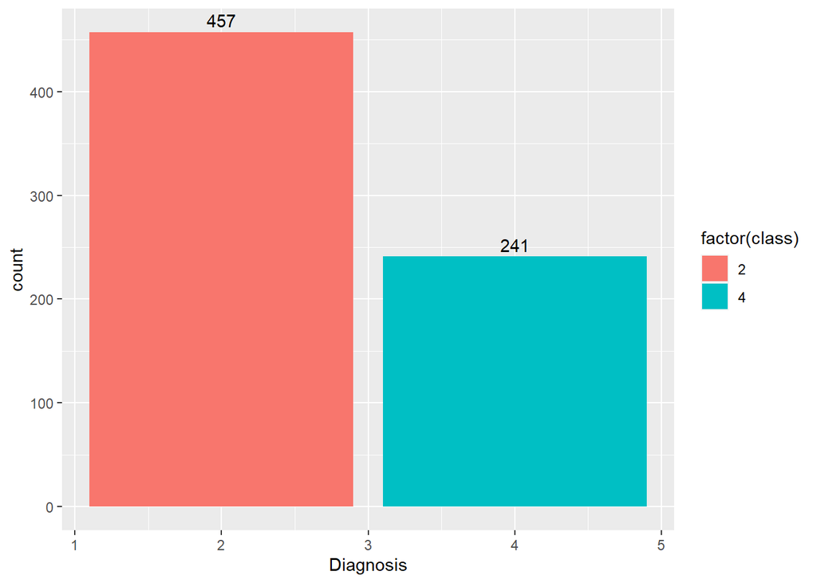

```r
ggplot(data = datarepl, aes(class, fill = factor(class)))+
  geom_bar() + xlab("Diagnosis") + geom_text(aes(label = ..count..), stat = 'count', vjust = -0.4)
```

### Data Pre-processing

#### Converting bare_nuclei from character datatype to int.

```r
datarepl$bare_nuclei <- as.integer(datarepl$bare_nuclei)
```

Some NA values have been inserted while changing the class of the above variable, which needs to be dropped before further analysis.

#### Dropping all na values

```r
datarepl <- na.omit(datarepl)
```

#### Changing class variable to binary 0 and 1

```r
datarepl$class <- ifelse(datarepl$class == 2,0,1)
```

### Building models

#### Doing train test split

```r
set.seed(100)
split1 <- sample.split(datarepl)
train1 <- subset(datarepl, split == 'TRUE')
train_features1 <- train1[-11]
test1 <- subset(datarepl, split == 'FALSE')
test_features1 <- test1[-11]
```

#### Feature importance check

```r
control <- trainControl(method="repeatedcv", number=10, repeats=3)
```

#### Training the model

```r
model1 <- train(class~., data=train1, method="knn", preProcess="scale", trControl=control)
```

#### Estimating variable importance

```r
importance <- varImp(model1, scale=FALSE)
```

#### Summarizing importance

```r
print(importance)
```

```
## loess r-squared variable importance
##
##                             Overall
## uniformity_of_cell_size     0.68679
## uniformity_of_cell_shape    0.66304
## bare_nuclei                 0.64347
## bland_chromatin             0.59197
## clump_Thickness             0.54119
## normal_nucleoli             0.49069
## single_epithelial_cell_size 0.48174
## marginal_adhesion           0.47631
## mitoses                     0.18412
## sample_code_number          0.05751
```

#### Plotting importance

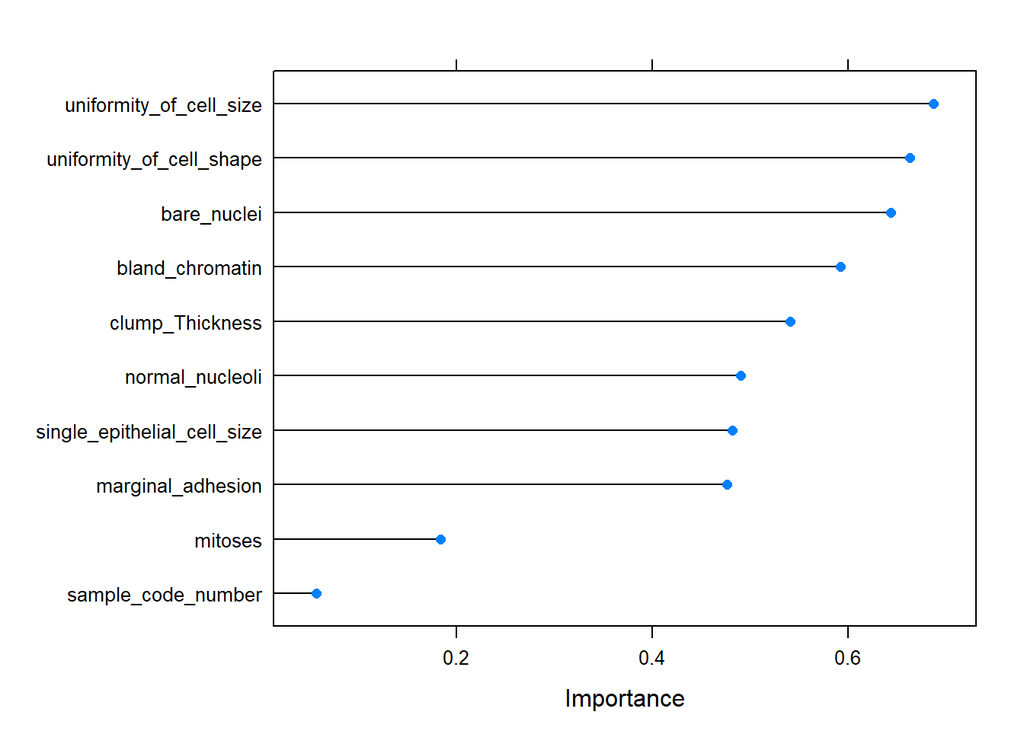

```r
plot(importance)
```

#### Checking which K value fits bets for our dataset.

```r
for (k in c(1:10)) {
  # Creating K-Nearest Neighbor Model...
  knn_model1 <- knn(train = train_features1[-10][-1],test = test_features1[-10][-1], cl = train1$class, k = k)
  # Confusion Matrix of KNN...
  cm3 <- table(test1$class, knn_model1)
  print(cm3)

  # Accuracy of KNN..
  misClassError <- mean(knn_model1 != test1$class)
  precision <- cm3[2,2]/(cm3[2,2]+cm3[2,1])
  recall <- cm3[2,2]/(cm3[2,2]+cm3[1,2])
  print(paste('k = ',k,' Accuracy =', 1-misClassError, ' precision = ',precision, ' recall = ', recall))
}
```

```
##    knn_model1
##       0   1
##   0 156   3
##   1   9  80
## [1] "k =  1  Accuracy = 0.951612903225806  precision =  0.898876404494382  recall =  0.963855421686747"
##    knn_model1
##       0   1
##   0 157   2
##   1   6  83
## [1] "k =  2  Accuracy = 0.967741935483871  precision =  0.932584269662921  recall =  0.976470588235294"
##    knn_model1
##       0   1
##   0 158   1
##   1   4  85
## [1] "k =  3  Accuracy = 0.979838709677419  precision =  0.955056179775281  recall =  0.988372093023256"
```

[output cut: 35 more lines]

#### Creating K-Nearest Neighbor Model

```r
knn_model1 <- knn(train = train_features1[-10][-1],test = test_features1[-10][-1], cl = train1$class, k = 5 )
```

#### Confusion Matrix of KNN

```r
cm4 <- table(test1$class, knn_model1)
cm4
```

```
##    knn_model1
##       0   1
##   0 158   1
##   1   5  84
```

#### Accuracy of KNN

```r
precision <- cm4[2,2]/(cm4[2,2]+cm4[2,1])
recall <- cm4[2,2]/(cm4[2,2]+cm4[1,2])
print(paste(' Accuracy =', 1-misClassError, ' precision = ',precision, ' recall = ', recall))
```

```
## [1] " Accuracy = 0.979838709677419  precision =  0.943820224719101  recall =  0.988235294117647"
```

Using feature selection technique has improved accuracy of the model significantly in comparison Reproduction of the original study.

Further more precision and recall have a high positive change,

#### Using Naive Bayes Algorithm

```r
nb_model1 <- naiveBayes(class ~ ., data = train1)
nb_model1
```

```
##
## Naive Bayes Classifier for Discrete Predictors
##
## Call:
## naiveBayes.default(x = X, y = Y, laplace = laplace)
##
## A-priori probabilities:
## Y
##         0         1
## 0.6543779 0.3456221
##
## Conditional probabilities:
##    sample_code_number
## Y        [,1]     [,2]
##   0 1083962.2 262630.4
##   1  969174.6 332727.2
##
##    clump_Thickness
## Y       [,1]     [,2]
##   0 3.066901 1.662015
##   1 7.433333 2.324127
##
##    uniformity_of_cell_size
## Y       [,1]      [,2]
##   0 1.327465 0.9446628
##   1 6.740000 2.6657912
##
##    uniformity_of_cell_shape
## Y       [,1]     [,2]
##   0 1.433099 1.011819
##   1 6.540000 2.605183
##
##    marginal_adhesion
## Y       [,1]      [,2]
##   0 1.320423 0.8972702
##   1 5.480000 3.3170699
##
##    single_epithelial_cell_size
## Y       [,1]      [,2]
##   0 2.130282 0.9551415
##   1 5.386667 2.4046562
##
##    bare_nuclei
## Y       [,1]     [,2]
##   0 1.394366 1.344838
##   1 7.526667 3.207995
##
##    bland_chromatin
## Y       [,1]     [,2]
##   0 2.080986 1.045159
##   1 6.000000 2.213443
##
##    normal_nucleoli
## Y       [,1]     [,2]
##   0 1.302817 1.066611
##   1 5.813333 3.427850
##
##    mitoses
## Y       [,1]      [,2]
##   0 1.059859 0.4603824
##   1 2.486667 2.3537395
```

#### Generating predictions

```r
prediction1 <- predict(nb_model1, newdata = test1[-11])
```

#### Confusion matrix for NB algorithm

```r
cm5 <- table(test1$class, prediction1)
cm5
```

```
##    prediction1
##       0   1
##   0 154   5
##   1   2  87
```

#### Accuracy of Naive Bayes

```r
correct_values <- cm5[1,1]+cm5[2,2]
total_values <- correct_values + cm5[1,2] + cm5[2,1]

acc <- correct_values/total_values
print(paste('Accuracy = ', acc))
```

```
## [1] "Accuracy =  0.971774193548387"
```

The accuracy is around 97 % which is almost equal to the one in Original Study.

#### Applying Logistic Regression Model

```r
log_model <- glm(class ~ ., data = train1, family = 'binomial')

summary(log_model)
```

```
##
## Call:
## glm(formula = class ~ ., family = "binomial", data = train1)
##
## Deviance Residuals:
##     Min       1Q   Median       3Q      Max
## -3.3745  -0.1236  -0.0605   0.0418   2.6018
##
## Coefficients:
##                               Estimate Std. Error z value Pr(>|z|)
## (Intercept)                 -9.785e+00  1.942e+00  -5.038  4.7e-07 ***
## sample_code_number          -2.373e-07  1.126e-06  -0.211 0.833156
## clump_Thickness              6.116e-01  1.771e-01   3.453 0.000554 ***
## uniformity_of_cell_size     -2.863e-02  2.193e-01  -0.131 0.896159
## uniformity_of_cell_shape     2.082e-01  2.372e-01   0.878 0.380005
## marginal_adhesion            1.139e-01  1.331e-01   0.856 0.391953
## single_epithelial_cell_size  6.454e-02  1.881e-01   0.343 0.731521
## bare_nuclei                  3.712e-01  1.118e-01   3.321 0.000896 ***
## bland_chromatin              5.935e-01  2.037e-01   2.914 0.003573 **
## normal_nucleoli              2.118e-01  1.236e-01   1.713 0.086646 .
## mitoses                      4.390e-01  4.648e-01   0.945 0.344904
## ---
## Signif. codes:  0 '***' 0.001 '**' 0.01 '*' 0.05 '.' 0.1 ' ' 1
##
## (Dispersion parameter for binomial family taken to be 1)
##
##     Null deviance: 559.59  on 433  degrees of freedom
## Residual deviance:  74.38  on 423  degrees of freedom
## AIC: 96.38
##
## Number of Fisher Scoring iterations: 8
```

#### Generating the Prediction for the model

```r
predict_reg <- predict(log_model,
                       test_features1, type = "response")
predict_reg
```

[output not shown]

[output cut: 29 more lines]

[output not shown]

```r
predict_reg <- ifelse(predict_reg >0.5, 1, 0)
```

#### Confusion matrix

```r
table(test1$class, predict_reg)
```

```
##    predict_reg
##       0   1
##   0 159   0
##   1   5  84
```

#### Finalizing Accuracy

```r
missing_classerr <- mean(predict_reg != test1$class)
print(paste('Accuracy =', 1 - missing_classerr))
```

```
## [1] "Accuracy = 0.979838709677419"
```

The accuracy is around 98 % which is high and was not utilized in the original study

### Areas of improvement

- Used Cross Validation Techniques and Feature selection techniques which improved our results drastically.
- For KNN model, not only accuracy improved but precision and recall took a major leap.
- It is also suggested to use Logistic regression for this problem as that ML model also give good stats in this case.
- Better if we use KNN model here with features selected for it.
- Visualization improved